# Dragonborn Heights

# What’s the standard deviation?

The PHB says that the average height of a dragonborn is 6ft. This doesn’t distinguish between males and females. Based on this, we have to assume that female dragonborns are the same average height as male dragonborns. What’s not given is the standard deviation or the variance assumed in the population. Because there isn’t a comparable real-world species, I’m just going to base this off of human variations in height. The major flaw I see in this approach is that humans likely have a wide variation because of the spread of human differences across the globe. There is not a consistent (given all the made up worlds) division of dragonborn nations, cultures, sub-species, etc. However, less variance just means that more will closer to 6’ rather than further. Making a 7’ dragonborn even more unlikely.

**I did a whole bunch of figuring with a dataset on human heights and realized it was all flawed from the the start. So, to get a standard deviation (SD), I’m using data from the CDC. [Link](https://www.cdc.gov/nchs/data/nhsr/nhsr122-508.pdf). They report heights and standard error of the mean, which doesn’t help me. But I can get SD from that.

For males 20-39 years of age, the mean height was 69.3 inches with SE of 0.1. The sample size for this statistic was 883. I also found an old study looking at the heights of men in the UK between 1770 and 1815. [Link](https://www.jstor.org/stable/2123399?seq=10#metadata_info_tab_contents). Here they reported around 65 inches with a SD of 2.44. Let’s see if I can get about the same from the CDC data. Just to verify my figurins’.

```r
cdc_mean <- 69.3
cdc_se <- 0.1
cdc_n <- 883
sqrt(cdc_n)*cdc_se
```

```
## [1] 2.971532
```

That’s fairly close. Especially since the CDC is looking at Americans between 2015 and 2016. There is bound to be more variability with Americans compared to UK in the late 1700s. Since it is DnD, which usually takes place in older settings, I’ll just go with 2.5 for the SD. Now with a SD in hand, we can generate a distribution for 100,000 dragonborns that is 1.) normally distributed as heights usually are and 2.) making the mean 6 feet or 72 inches and the SD 2.5.

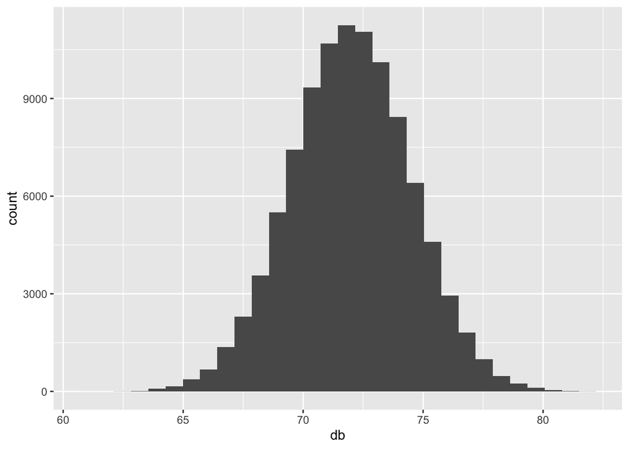

```r
db_hgt <- data.frame(db = rnorm(100000, mean = 72, sd = 2.5))
db_hgt %>% ggplot(aes(db)) +
  geom_histogram()
```

# How likely is it to see a 7’ dragonborn?

Well that’s a beautifully normal distribution. From just glancing at this we can see that even 80" (6’6“) is remarkably rare. But we can go a bit further and calculate the probability of seeing a 84”(7’) dragonborn given this data. To do that we need a few things:

```r
Z <- (84-72)/2.5
pnorm(84, mean = 72, sd = 2.5, lower.tail = FALSE)
```

```
## [1] 7.933282e-07
```